# Random Forest

Syed Jafar Raza Rizvi NSID: cfr954 Student ID: 11344782

2025-02-11

Data Wrangling

Load your dataset and examine its structure. Perform cleaning tasks, including handling missing data, correcting inconsistencies, and ensuring appropriate data types. Prepare the dataset for analysis by creating or transforming variables as necessary.

## Dataset Exploration

Load and examine **the synthetic cohort of ~100,000 patients**.

```r
data_synt <- read_excel("synthetic_data_stats_competition_2025_final.xlsx")
```

**Check the structure of the dataset**

```r
dim(data_synt)
```

```
## [1] 106747    138
```

```r
df_info <- data.frame(
  Variable = names(data_synt),
  Type = sapply(data_synt, class)  # Gets the data type of each variable
)
print(df_info, row.names = FALSE)  # Print full output
```

```
##                                       Variable      Type
##                                     patient_id character
##                     demographics_age_index_ecg   numeric
##                         demographics_birth_sex   numeric
##                             hypertension_icd10   numeric
##                              diabetes_combined   numeric
##                          dyslipidemia_combined   numeric
##                                      dcm_icd10   numeric
##                                      hcm_icd10   numeric
##                        myocarditis_icd10_prior   numeric
##                       pericarditis_icd10_prior   numeric
##                          aortic_aneurysm_icd10   numeric
##                  aortic_dissection_icd10_prior   numeric
##                            pulmonary_htn_icd10   numeric
##                                  amyloid_icd10   numeric
##                                     copd_icd10   numeric
##                 obstructive _sleep_apnea_icd10   numeric
##                             hyperthyroid_icd10   numeric
##                              hypothyroid_icd10   numeric
##                     rheumatoid_arthritis_icd10   numeric
##                                      sle_icd10   numeric
##                                  sarcoid_icd10   numeric
##                               cancer_any_icd10   numeric
##              event_cv_hf_admission_icd10_prior   numeric
##          event_cv_cad_acs_acute_mi_icd10_prior   numeric
##   event_cv_cad_acs_unstable_angina_icd10_prior   numeric
##             event_cv_cad_acs_other_icd10_prior   numeric
##                 event_cv_ep_vt_any_icd10_prior   numeric
##       event_cv_ep_sca_survived_icd10_cci_prior   numeric
##       event_cv_cns_stroke_ischemic_icd10_prior   numeric
##        event_cv_cns_stroke_hemorrh_icd10_prior   numeric
##                   event_cv_cns_tia_icd10_prior   numeric
##                                      pci_prior   numeric
##                                     cabg_prior   numeric
##                     transplant_heart_cci_prior   numeric
##                                 lvad_cci_prior   numeric
##                  pacemaker_permanent_cci_prior   numeric
##                                  crt_cci_prior   numeric
##                                  icd_cci_prior   numeric
##                                 ecg_resting_hr   numeric
```

[output cut: 84 more lines]

```
##                     glucose_ohg_biguanide_peri   numeric
##                     glucose_ohg_alphagluc_peri   numeric
##                         glucose_ohg_dpp_4_peri   numeric
##                        glucose_ohg_sglt_2_peri   numeric
##                  glucose_ohg_thiazolidine_peri   numeric
##                   glucose_ohg_repaglinide_peri   numeric
##                  glucose_ohg_sulfonylurea_peri   numeric
##                         glucose_ohg_other_peri   numeric
##                    smoking_cessation_oral_peri   numeric
##    smoking_cessation_nicotine_replacement_peri   numeric
##                 outcome_afib_aflutter_new_post   numeric
##         time_to_outcome_afib_aflutter_new_post   numeric
##                        outcome_all_cause_death   numeric
##                time_to_outcome_all_cause_death   numeric
##                             follow_up_duration   numeric
```

```r
get_unique_values <- function(df, vars_to_exclude = NULL) {
  # Initialize results dataframe
  result <- data.frame(
    Variable_Name = character(),
    Unique_Values = character(),
    Is_Boolean = logical(),
    # Value_Count = integer(),
    stringsAsFactors = FALSE
  )

  # Get columns to analyze (excluding specified vars)
  cols_to_analyze <- setdiff(names(df), vars_to_exclude)

  for (col in cols_to_analyze) {
    # Get complete unique values (including NA)
    unique_vals <- unique(df[[col]])
    na_present <- any(is.na(unique_vals))
    na_sum<-sum(is.na(df[[col]]))
    na_sum_per<-((sum(is.na(df[[col]])))/length(df[[col]]))*100

    # Remove NA for boolean detection
    clean_vals <- unique_vals[!is.na(unique_vals)]
    val_count <- length(clean_vals)

    # Detect boolean variables (0/1 or 1/2 numeric)
    is_boolean <- if (val_count <= 2 && is.numeric(df[[col]])) {
      all(clean_vals %in% c(0, 1)) || all(clean_vals %in% c(1, 2))
    } else {
      FALSE
    }

    # Prepare values for display
    if (na_present) {
      display_vals <- c(sort(clean_vals), NA)
    } else {
      display_vals <- sort(clean_vals)
    }

    # Convert to character representation
    char_vals <- sapply(display_vals, function(x) {
      if (is.na(x)) "NA" else as.character(x)
    })

    result <- rbind(result, data.frame(
      Variable_Name = col,
      Unique_Values = paste(char_vals, collapse = ", "),
      Is_Boolean = is_boolean,
      Value_Count = val_count,
      missing=na_sum,
      missing_per=na_sum_per,
      stringsAsFactors = FALSE
    ))
  }

  return(result)
}
unique_values <- get_unique_values(data_synt)
table(unique_values$Is_Boolean)
```

```
##
## FALSE  TRUE
##    44    94
```

[output not shown]

**Missing Data Information**

```r
missing_table <- miss_var_summary(data_synt)
missing_table
```

```
## # A tibble: 138 × 3
##    variable                               n_miss pct_miss
##    <chr>                                   <int>    <num>
##  1 bilirubin_direct_peri                  105668     99.0
##  2 crp_high_sensitive_peri                103962     97.4
##  3 NTproBNP_peri_highest                  102515     96.0
##  4 time_to_outcome_afib_aflutter_new_post 100256     93.9
##  5 esr_peri                                96159     90.1
##  6 urine_alb_cr_ratio_peri                 92369     86.5
##  7 aspartate_transaminase_peri             89967     84.3
##  8 troponin_t_hs_peri_highest              79055     74.1
##  9 time_to_outcome_all_cause_death         78309     73.4
## 10 ck_peri                                 78306     73.4
## # ℹ 128 more rows
```

In this missing data **time_to_outcome_afib_aflutter_new_post** which is **Time from index 12 lead ECG to new onset atrial fibrillation/flutter**. This variable is blank if the patient did not develop the outcome and **time_to_outcome_all_cause_death** which is **Time from index 12 lead ECG to all cause death**. This variable is Blank if the patient did not die. So we can say that those missing is the conditional missing. so we can exclude them as a missing variables.

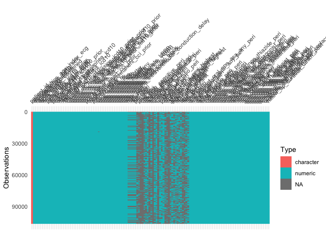

```r
data_synt1 <- data_synt %>%
  select(-c(time_to_outcome_afib_aflutter_new_post,time_to_outcome_all_cause_death))

vis_dat(data_synt1, warn_large_data = FALSE)
```

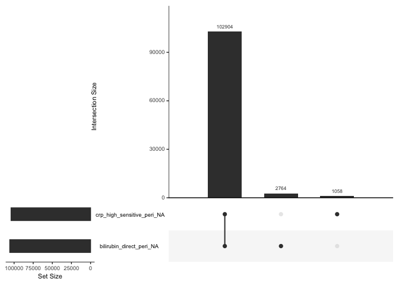

```r
gg_miss_upset(data_synt1, order.by = "freq", nsets = 2,  nintersects = 10)
```

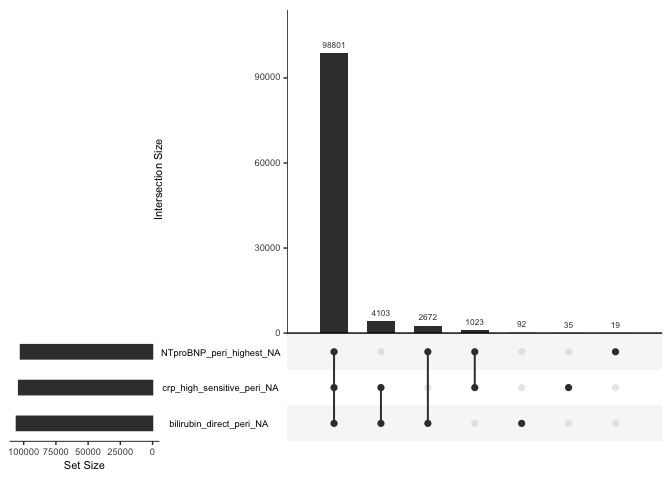

```r
gg_miss_upset(data_synt1, order.by = "freq", nsets = 3,  nintersects = 10)
```

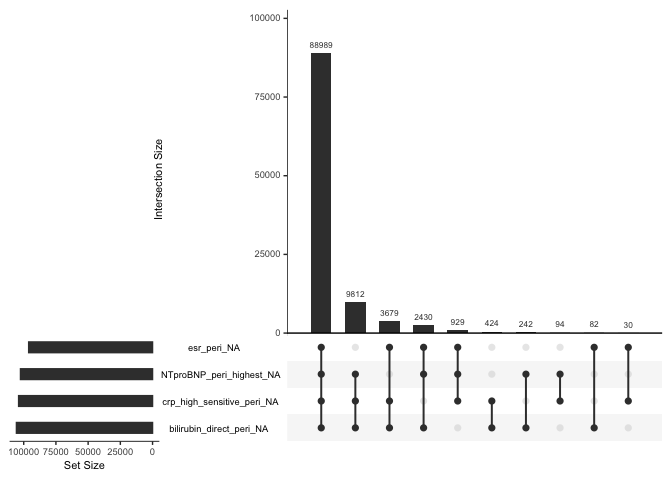

```r
gg_miss_upset(data_synt1, order.by = "freq", nsets = 4,  nintersects = 10)
```

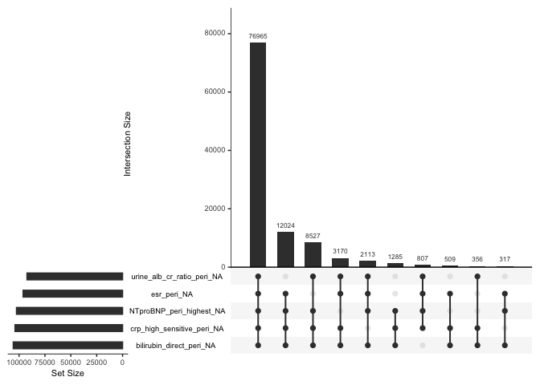

```r
gg_miss_upset(data_synt1, order.by = "freq", nsets = 5,  nintersects = 10)
```

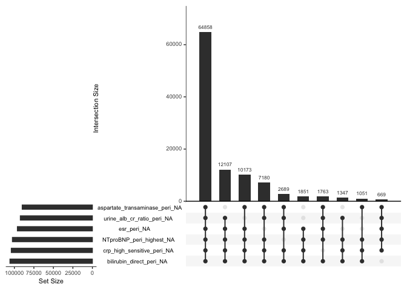

```r
gg_miss_upset(data_synt1, order.by = "freq", nsets = 6,  nintersects = 10)
```

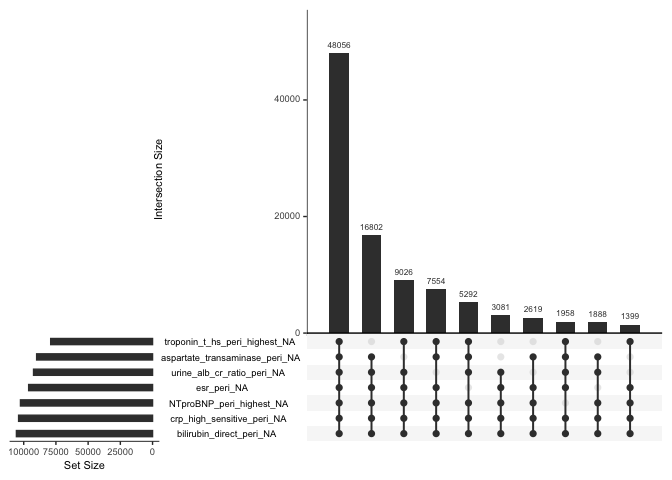

```r
gg_miss_upset(data_synt1, order.by = "freq", nsets = 7,  nintersects = 10)
```

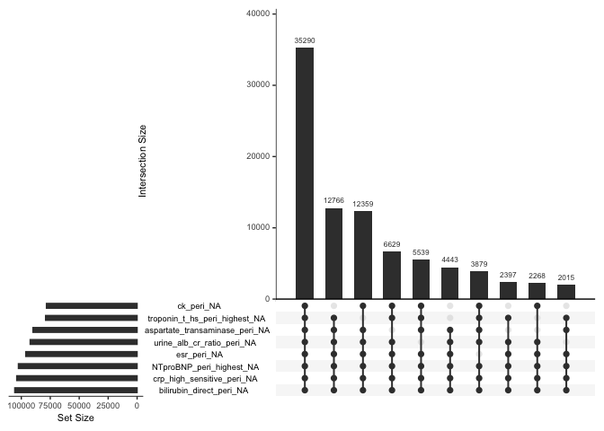

```r
gg_miss_upset(data_synt1, order.by = "freq", nsets = 8,  nintersects = 10)
```

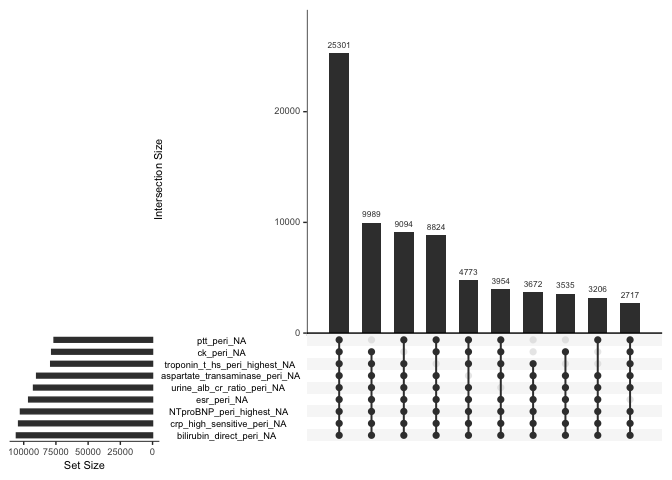

```r
gg_miss_upset(data_synt1, order.by = "freq", nsets = 9,  nintersects = 10)
```

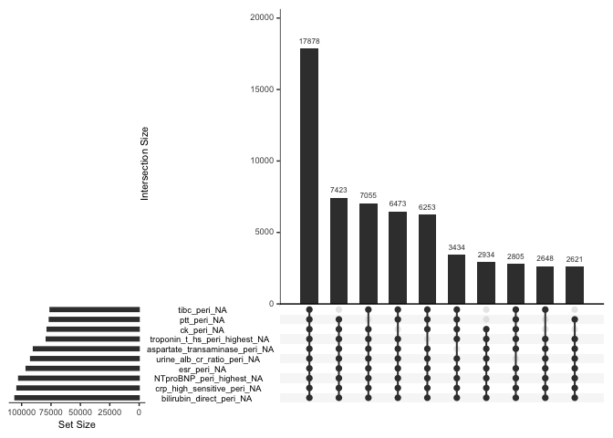

```r
gg_miss_upset(data_synt1, order.by = "freq", nsets = 10,  nintersects = 10)
```

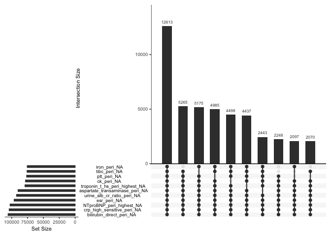

```r
gg_miss_upset(data_synt1, order.by = "freq", nsets = 11,  nintersects = 10)
```

[output not shown]

```r
# data_synt$time_to_outcome_afib_aflutter_new_post<-NULL
# data_synt$outcome_all_cause_death<-NULL
# data_synt$time_to_outcome_all_cause_death<-NULL
```

From this graph we can say that some specific variables which is the lab variables are missing.